# Supplementary Figures

Alex Pate

2025-02-17

Associated manuscript: Calibration plots for clinical prediction models predicting a survival outcome, and the role of covariate dependent censoring.

# Tables for main analysis

The main analysis had the following input parameters:

- Stopped Cox (individuals in validation cohort censored at the time point calibration is being assessed
- Coefficients 0.3/0.12
- No unmeasured dependence
- t = 0.25, time at which calibration assessed

Note, these match Figures 1, 2, 3 and 4 from the main manuscript.

**Figure S1.1: Calibration plots under C-DGM-R, and input parameters detailed in section introduction**

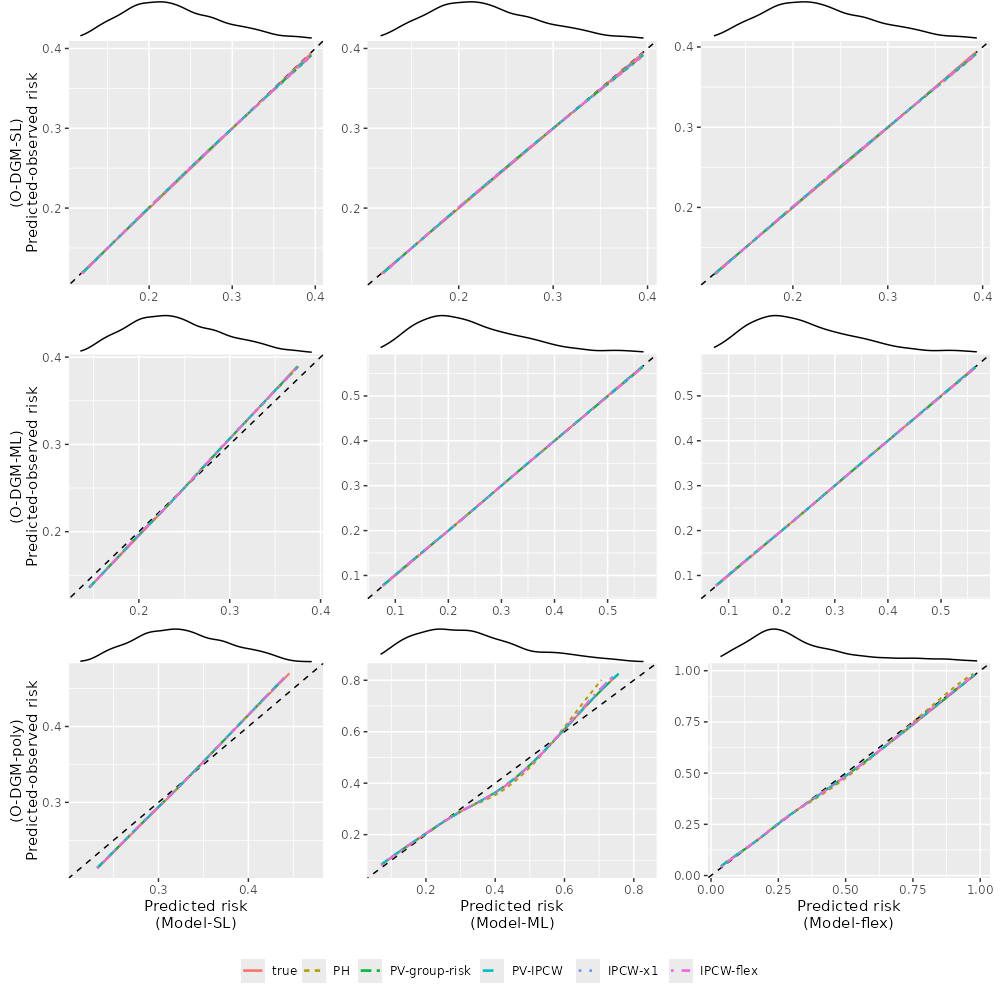

**Figure S1.2: Calibration plots under C-DGM-SL, and input parameters detailed in section introduction**

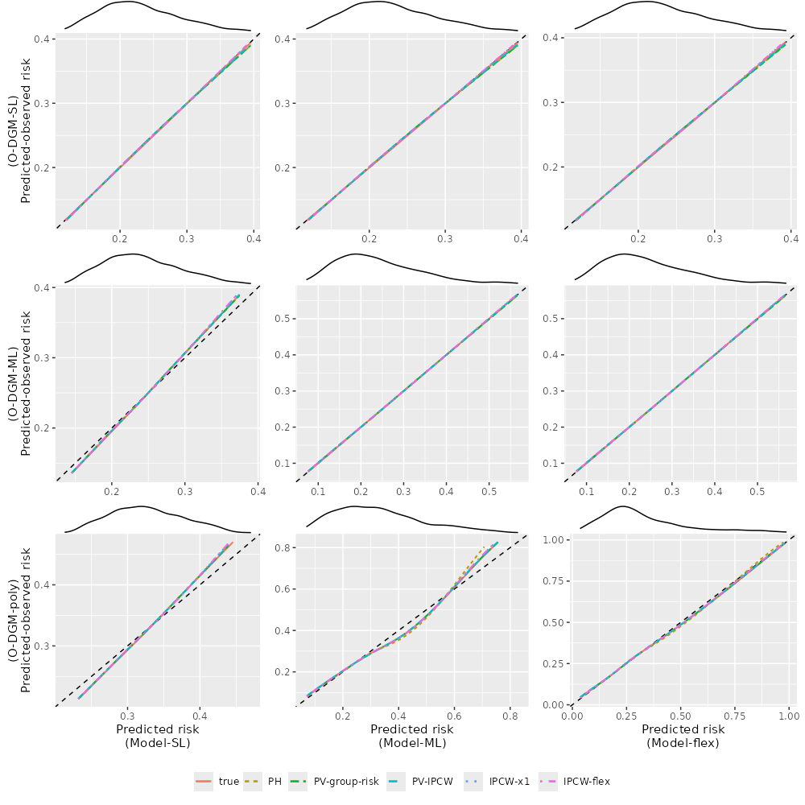

**Figure S1.3: Calibration plots under C-DGM-ML, and input parameters detailed in section introduction**

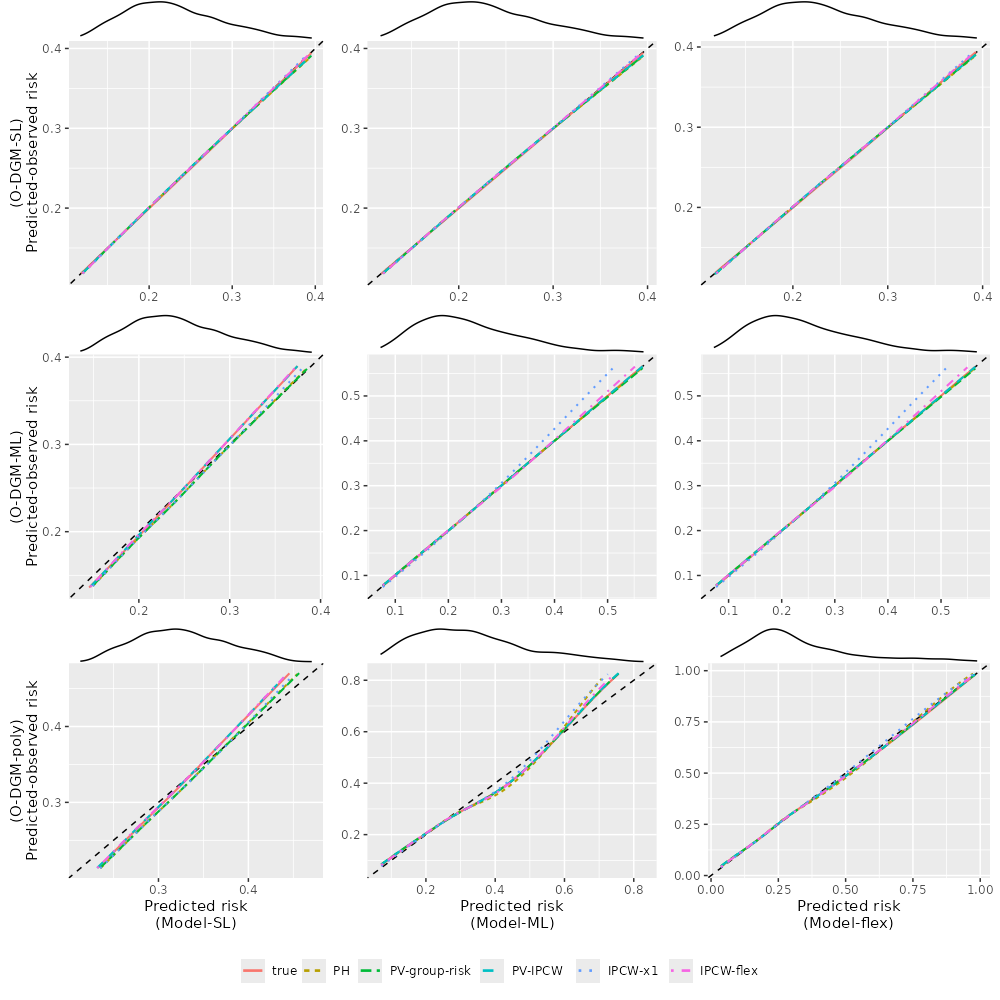

**Figure S1.4: Calibration plots under C-DGM-QU, and input parameters detailed in section introduction**

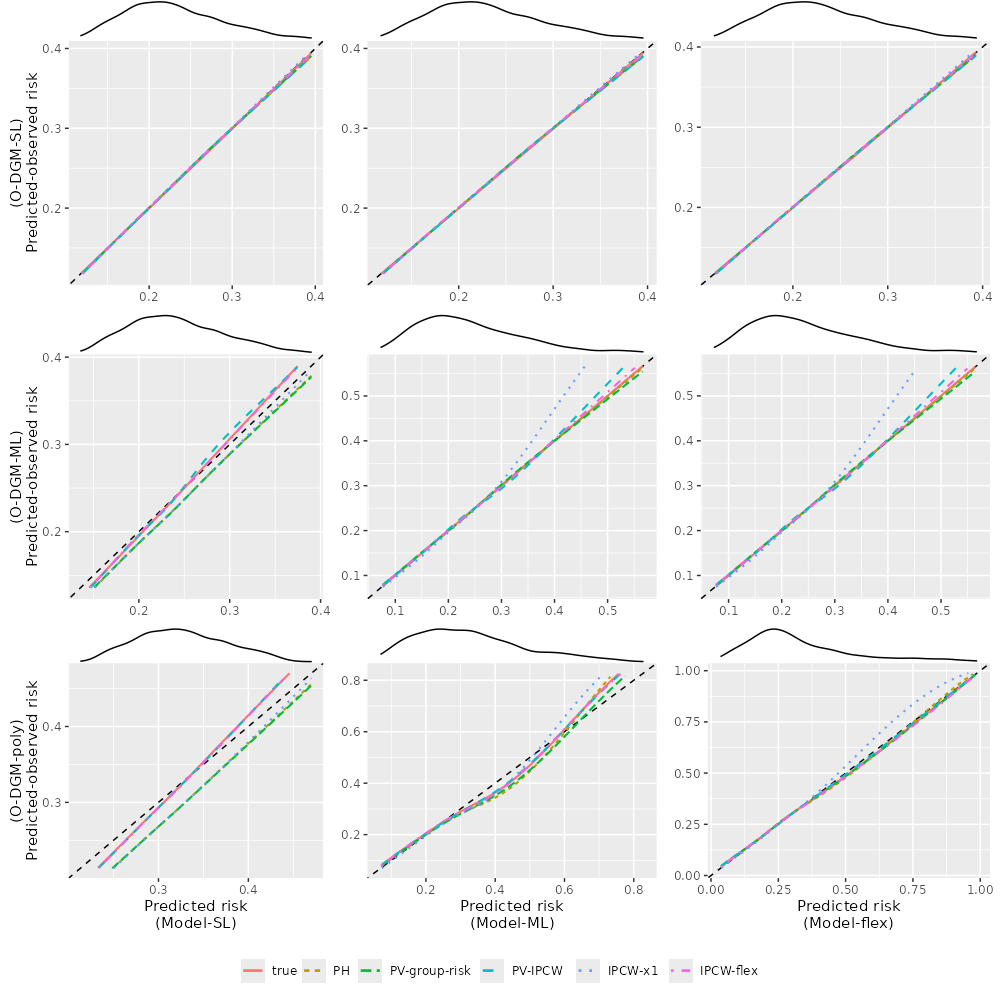

# Plots for sensitivity analyses

In each supplementary analysis, aside from the stated input parameter, all other input parameters remained the same as the main analysis.

## No stopped Cox

Individuals in validation cohort were not censored at the time point calibration is being assessed, i.e., stopped Cox not applied in validation cohort. Otherwise, input parameters same as main analysis.

**Figure S2.1: Calibration plots under C-DGM-R, and input parameters detailed in section introduction**

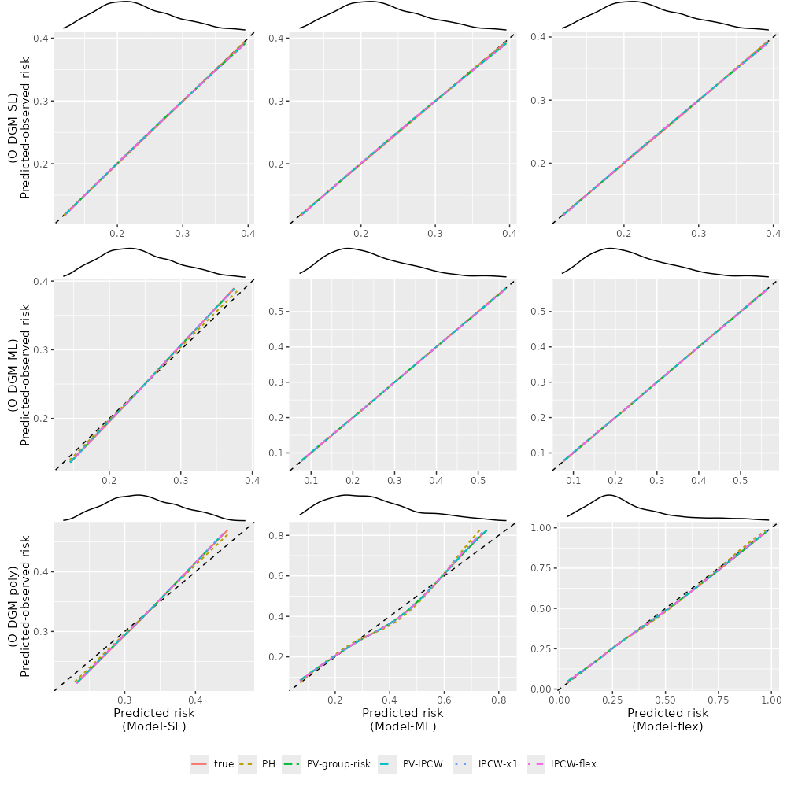

**Figure S2.2: Calibration plots under C-DGM-SL, and input parameters detailed in section introduction**

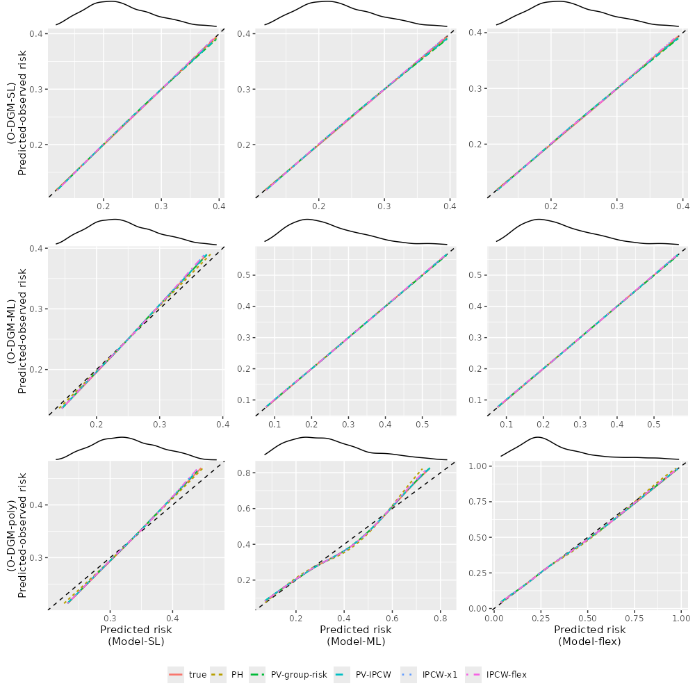

**Figure S2.3: Calibration plots under C-DGM-ML, and input parameters detailed in section introduction**

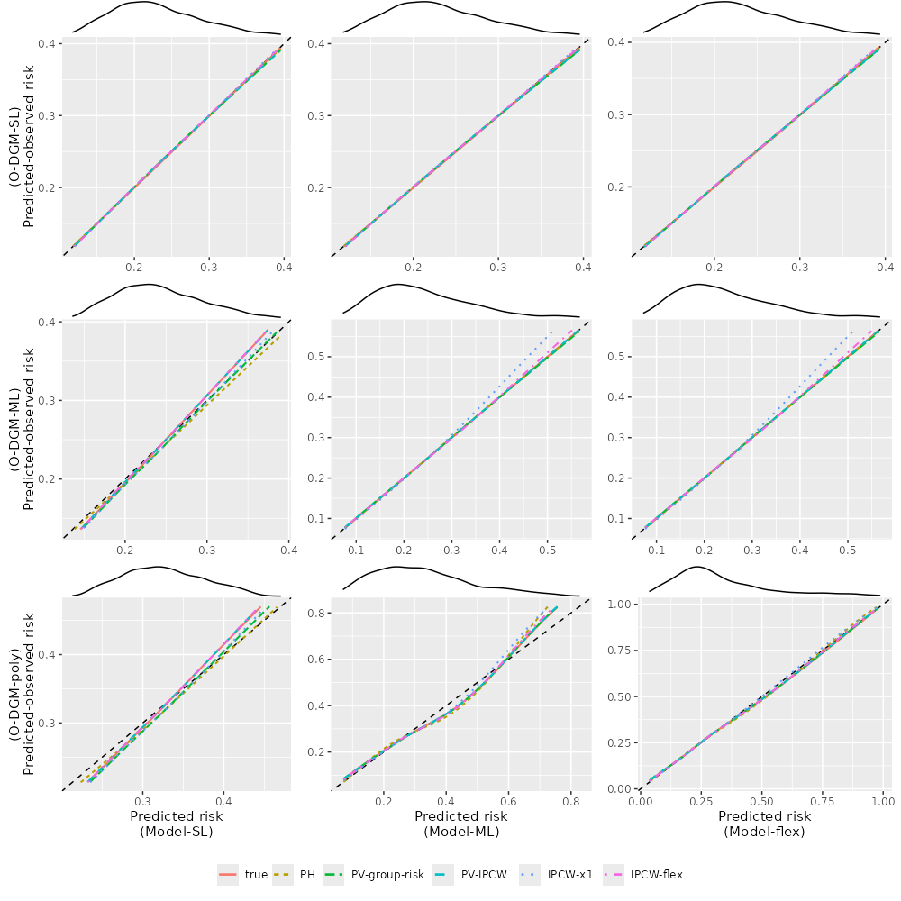

**Figure S2.4: Calibration plots under C-DGM-QU, and input parameters detailed in section introduction**

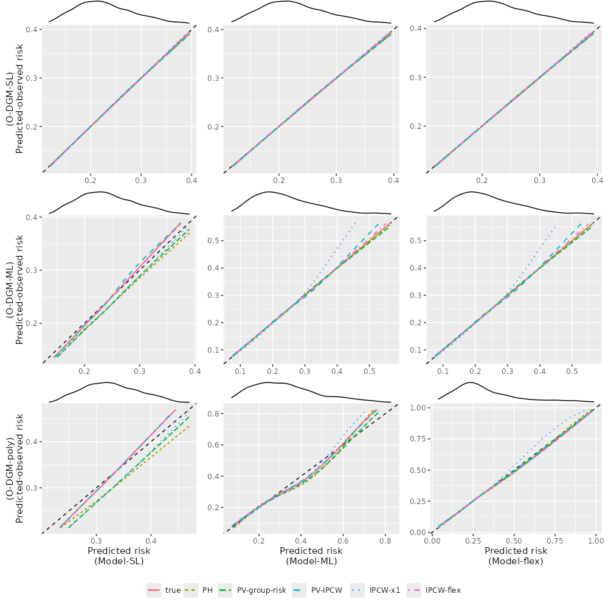

## Coefficients 0.5/0.2

Coefficients of 0.5/0.2 as opposed to Coefficients 0.3/0.12 in the data generating mechanisms. Otherwise, input parameters same as main analysis.

**Figure S3.1: Calibration plots under C-DGM-R, and input parameters detailed in section introduction**

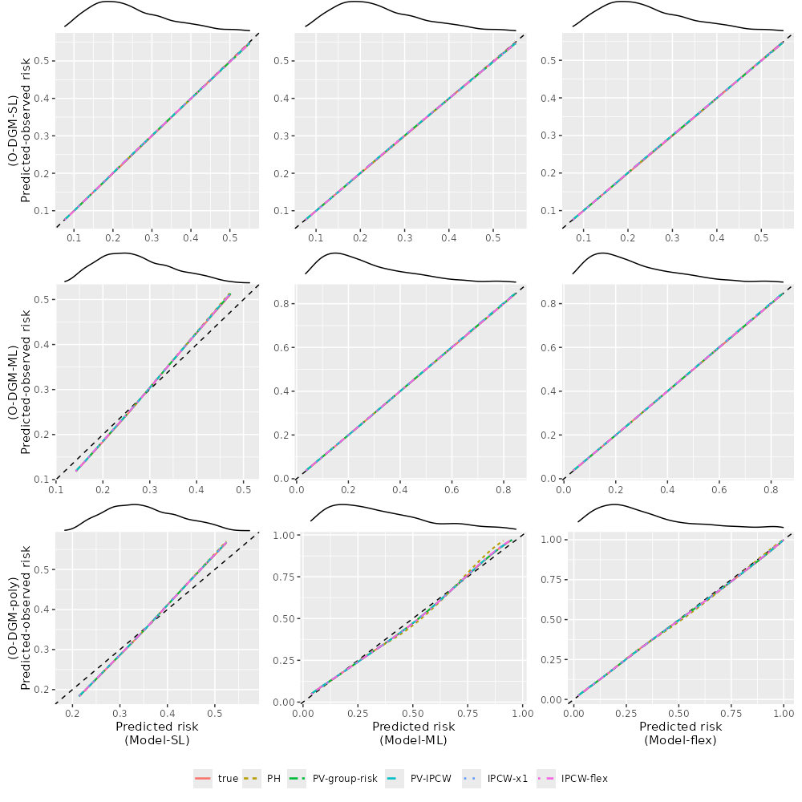

**Figure S3.2: Calibration plots under C-DGM-SL, and input parameters detailed in section introduction**

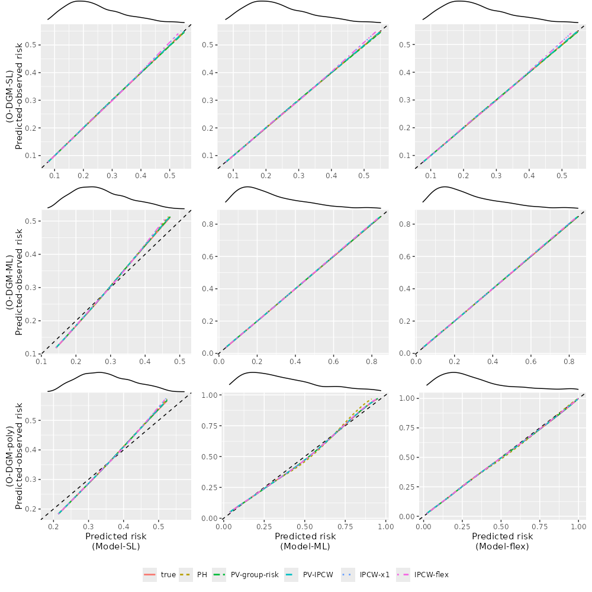

**Figure S3.3: Calibration plots under C-DGM-ML, and input parameters detailed in section introduction**

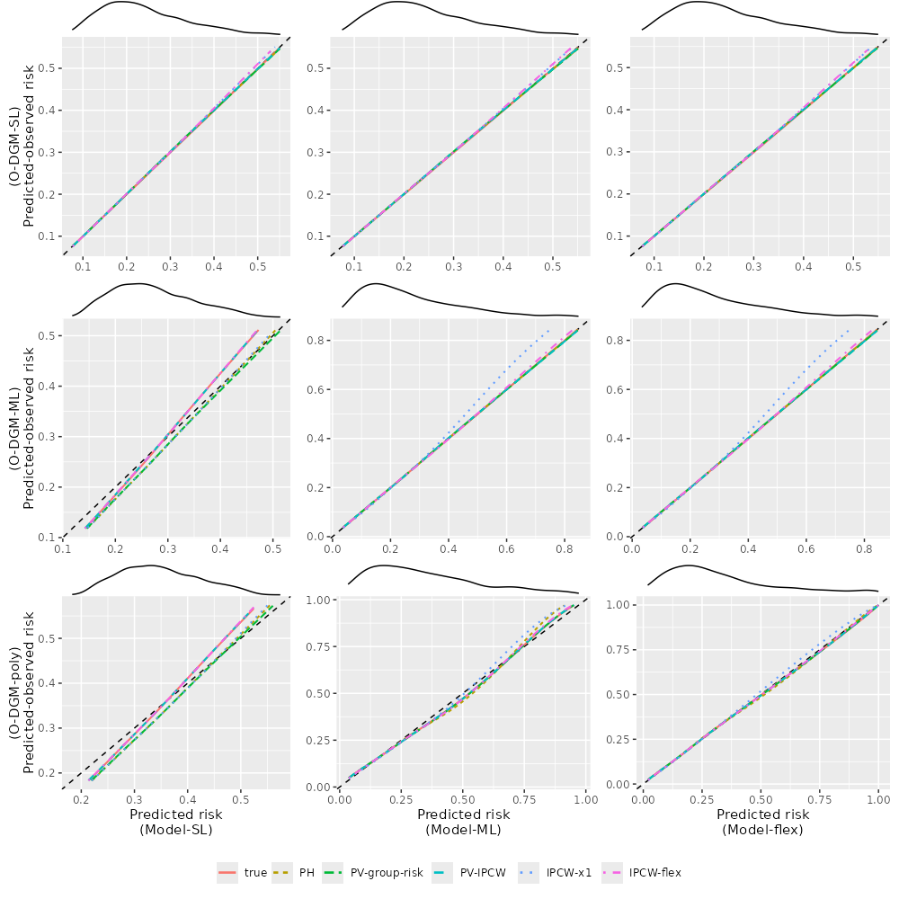

**Figure S3.4: Calibration plots under C-DGM-QU, and input parameters detailed in section introduction**

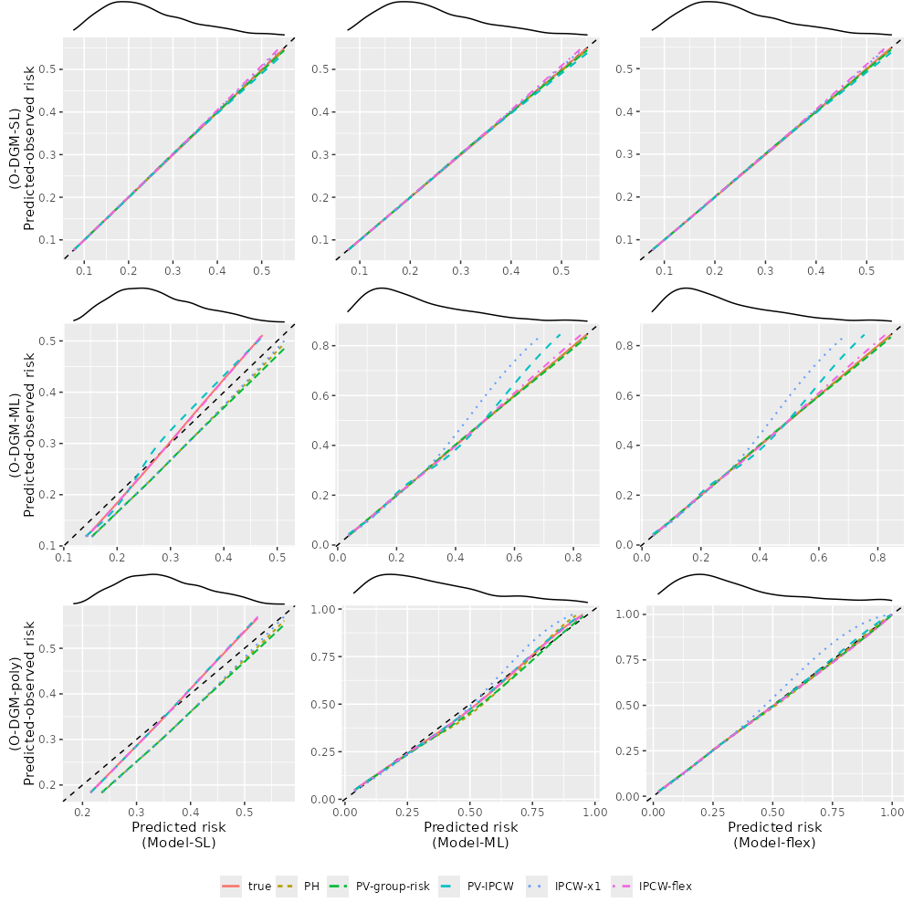

## Unmeasured dependence

Unmeasured dependence between the outcome and censoring mechanisms. Otherwise, input parameters same as main analysis.

**Figure S4.1: Calibration plots under C-DGM-R, and input parameters detailed in section introduction**

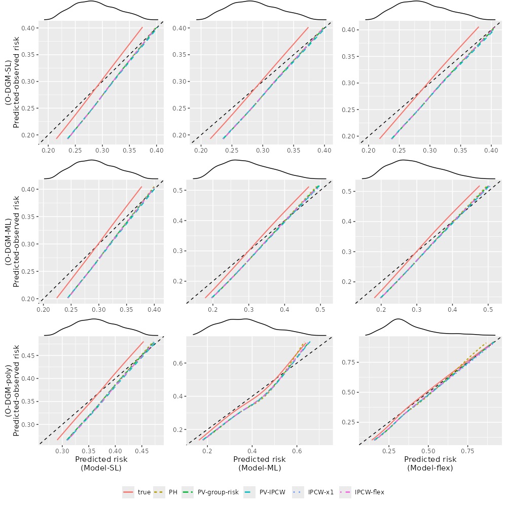

**Figure S4.2: Calibration plots under C-DGM-SL, and input parameters detailed in section introduction**

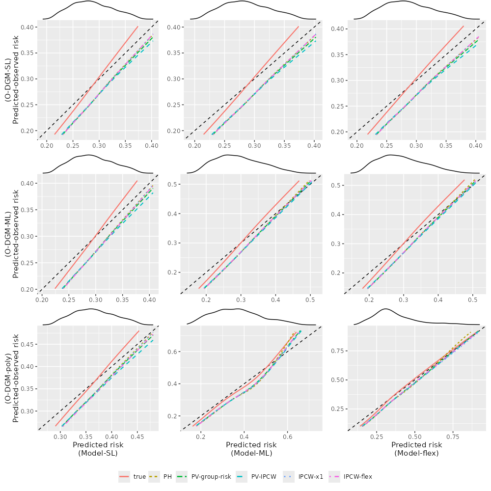

**Figure S4.3: Calibration plots under C-DGM-ML, and input parameters detailed in section introduction**

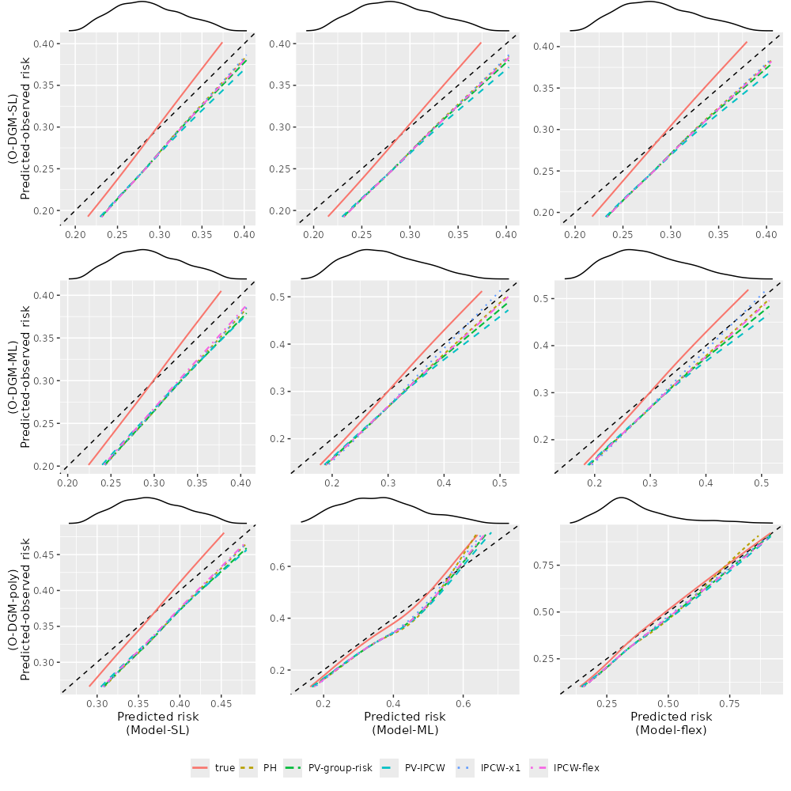

**Figure S4.4: Calibration plots under C-DGM-QU, and input parameters detailed in section introduction**

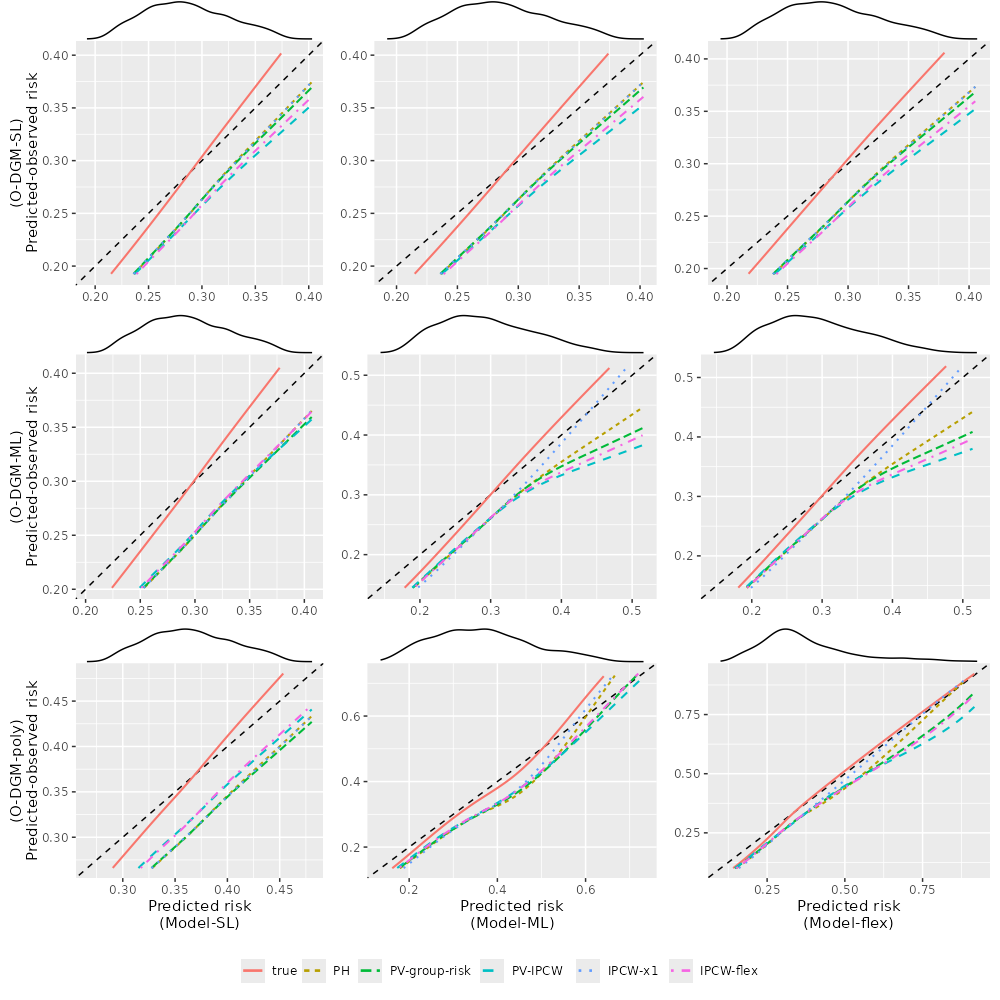

## t = 0.5

Calibration assessed at time point t = 0.5. Otherwise, input parameters same as main analysis.

**Figure S5.1: Calibration plots under C-DGM-R, and input parameters detailed in section introduction**

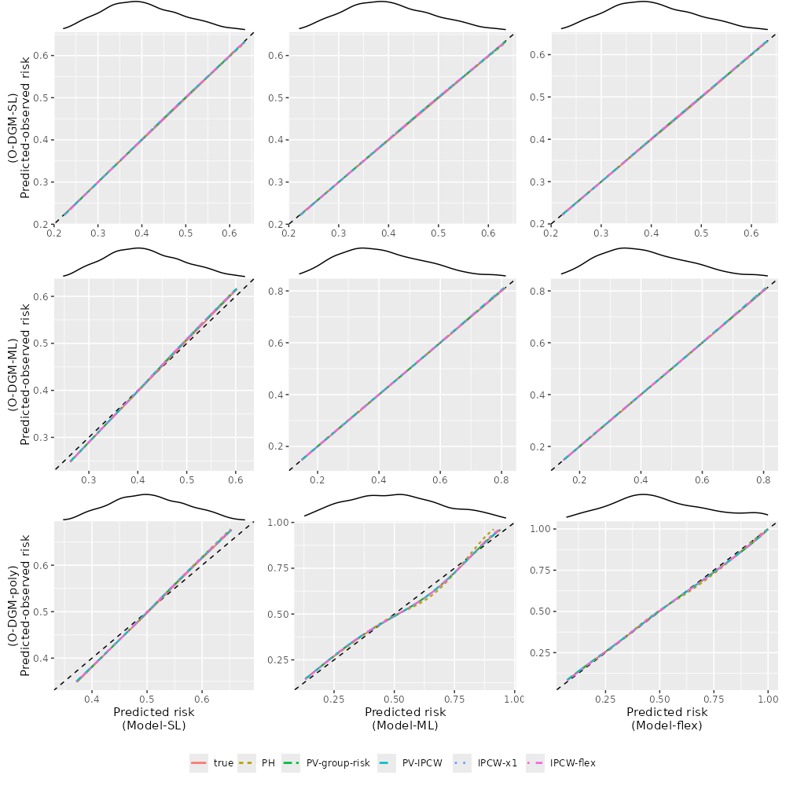

**Figure S5.2: Calibration plots under C-DGM-SL, and input parameters detailed in section introduction**

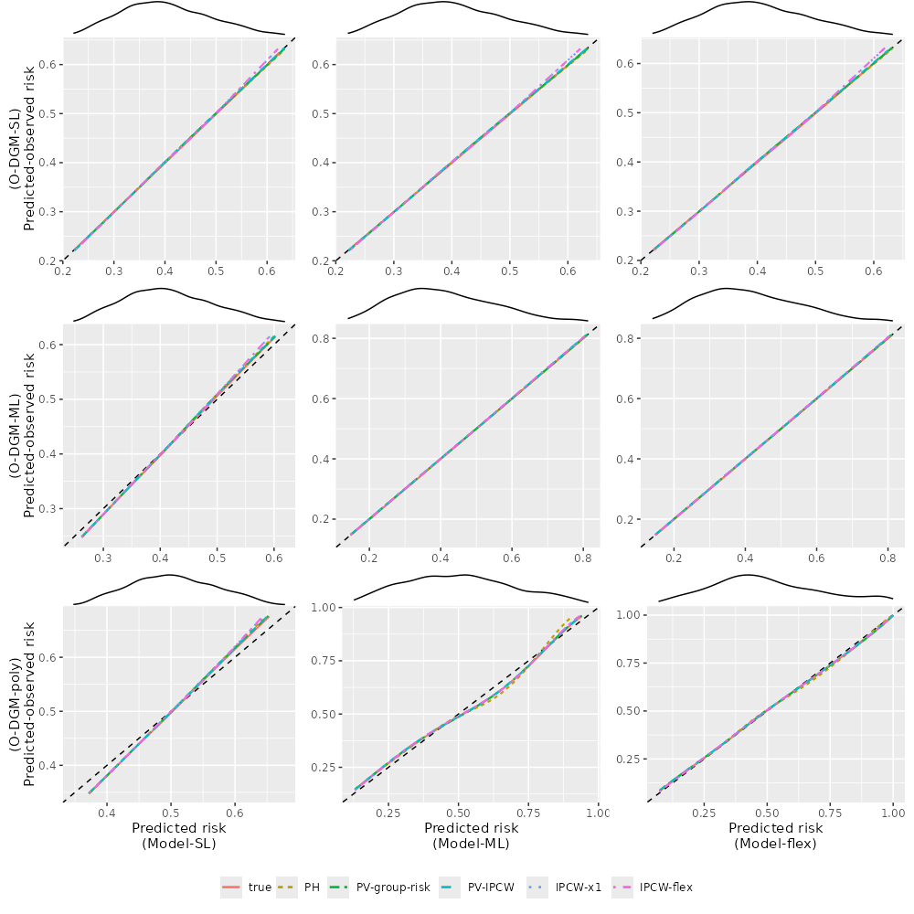

**Figure S5.3: Calibration plots under C-DGM-ML, and input parameters detailed in section introduction**

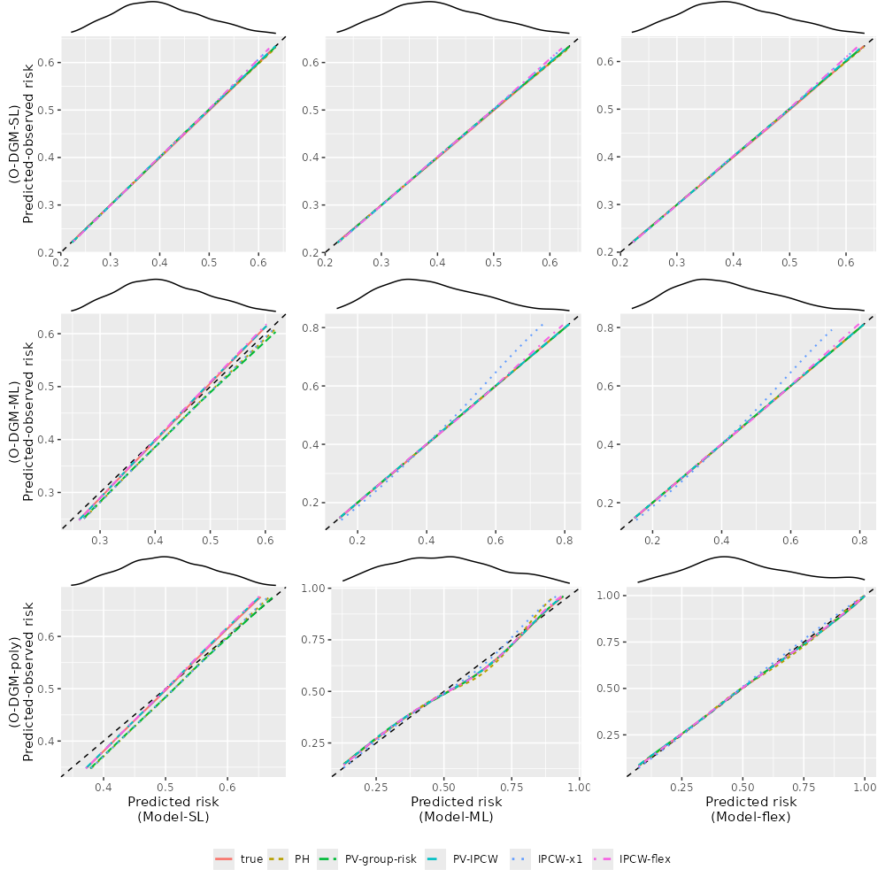

**Figure S5.4: Calibration plots under C-DGM-QU, and input parameters detailed in section introduction**

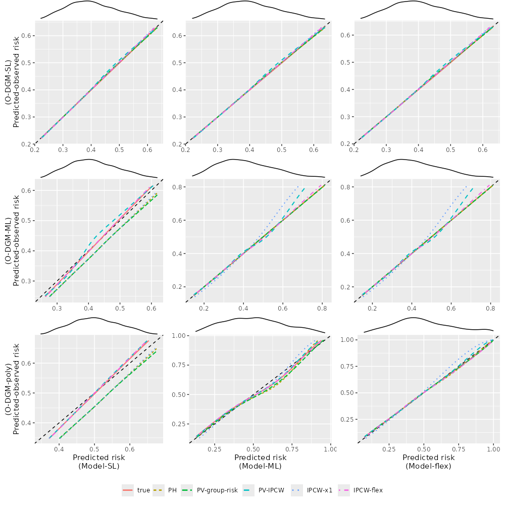